# Customer Rating of Breakfast Cereals

# Problem Statement

The dataset Cereals.csv includes nutritional information, store display, and consumer ratings for 77 breakfast cereals.

- Data Preprocessing. Remove all cereals with missing values.
- Apply hierarchical clustering to the data using Euclidean distance to the normalized measurements. Use Agnes to compare the clustering from single linkage, complete linkage, average linkage, and Ward. Choose the best method.
- How many clusters would you choose?
- Comment on the structure of the clusters and on their stability. Hint: To check stability, partition the data and see how well clusters formed based on one part apply to the other part. To do this:
- Cluster partition A
- Use the cluster centroids from A to assign each record in partition B (each record is assigned to the cluster with the closest centroid).
- Assess how consistent the cluster assignments are compared to the assignments based on all the data.
- The elementary public schools would like to choose a set of cereals to include in their daily cafeterias. Every day a different cereal is offered, but all cereals should support a healthy diet. For this goal, you are requested to find a cluster of “healthy cereals.” Should the data be normalized? If not, how should they be used in the cluster analysis?

Some code in this package comes from the following reference:

- https://www.dataminingbook.com/book/r-edition

Install packages if necessary. Uncomment before running.

```r
library(caret)
library(cluster) # for Agnes
```

## Data Processing

```r
cereals.df <- read.csv("./Cereals.csv")
cereals.df.nm <- na.omit(cereals.df)
head(cereals.df.nm)
```

|  | name | mfr | type | calories | protein | fat | sodium | fiber | carbo | sugars | potass | vitamins | shelf | weight | cups | rating |
| --- | --- | --- | --- | --- | --- | --- | --- | --- | --- | --- | --- | --- | --- | --- | --- | --- |
| 1 | 100%_Bran | N | C | 70 | 4 | 1 | 130 | 10.0 | 5.0 | 6 | 280 | 25 | 3 | 1 | 0.33 | 68.40297 |
| 2 | 100%_Natural_Bran | Q | C | 120 | 3 | 5 | 15 | 2.0 | 8.0 | 8 | 135 | 0 | 3 | 1 | 1.00 | 33.98368 |
| 3 | All-Bran | K | C | 70 | 4 | 1 | 260 | 9.0 | 7.0 | 5 | 320 | 25 | 3 | 1 | 0.33 | 59.42551 |
| 4 | All-Bran_with_Extra_Fiber | K | C | 50 | 4 | 0 | 140 | 14.0 | 8.0 | 0 | 330 | 25 | 3 | 1 | 0.50 | 93.70491 |
| 6 | Apple_Cinnamon_Cheerios | G | C | 110 | 2 | 2 | 180 | 1.5 | 10.5 | 10 | 70 | 25 | 1 | 1 | 0.75 | 29.50954 |
| 7 | Apple_Jacks | K | C | 110 | 2 | 0 | 125 | 1.0 | 11.0 | 14 | 30 | 25 | 2 | 1 | 1.00 | 33.17409 |

```r
# Normalize
cereals.df.nm.norm <- scale(cereals.df.nm[,-c(1:3)])
summary(cereals.df.nm.norm)
```

```
    calories          protein              fat              sodium            fiber              carbo
 Min.   :-2.8738   Min.   :-1.40687   Min.   :-0.9932   Min.   :-1.9616   Min.   :-0.89778   Min.   :-2.50014
 1st Qu.:-0.3541   1st Qu.:-0.47733   1st Qu.:-0.9932   1st Qu.:-0.3306   1st Qu.:-0.79462   1st Qu.:-0.70143
 Median : 0.1498   Median :-0.01256   Median : 0.0000   Median : 0.2131   Median :-0.07249   Median :-0.05903
 Mean   : 0.0000   Mean   : 0.00000   Mean   : 0.0000   Mean   : 0.0000   Mean   : 0.00000   Mean   : 0.00000
 3rd Qu.: 0.1498   3rd Qu.: 0.45221   3rd Qu.: 0.0000   3rd Qu.: 0.6661   3rd Qu.: 0.34015   3rd Qu.: 0.58337
 Max.   : 2.6695   Max.   : 3.24083   Max.   : 3.9729   Max.   : 1.9045   Max.   : 4.87925   Max.   : 2.12512
     sugars            potass           vitamins           shelf             weight             cups
 Min.   :-1.6306   Min.   :-1.1783   Min.   :-1.3032   Min.   :-1.4617   Min.   :-3.4600   Min.   :-2.4251
 1st Qu.:-0.9424   1st Qu.:-0.8079   1st Qu.:-0.1818   1st Qu.:-1.1612   1st Qu.:-0.2008   1st Qu.:-0.6432
 Median :-0.0248   Median :-0.1201   Median :-0.1818   Median :-0.2599   Median :-0.2008   Median :-0.3038
 Mean   : 0.0000   Mean   : 0.0000   Mean   : 0.0000   Mean   : 0.0000   Mean   : 0.0000   Mean   : 0.0000
 3rd Qu.: 0.8928   3rd Qu.: 0.3031   3rd Qu.:-0.1818   3rd Qu.: 0.9420   3rd Qu.:-0.2008   3rd Qu.: 0.7568
 Max.   : 1.8104   Max.   : 3.2660   Max.   : 3.1822   Max.   : 0.9420   Max.   : 3.0583   Max.   : 2.8780
     rating
 Min.   :-1.7336
 1st Qu.:-0.7071
 Median :-0.1510
 Mean   : 0.0000
 3rd Qu.: 0.5807
 Max.   : 3.6578
```

## Apply Agnes

```r
hc_single <- agnes(cereals.df.nm.norm, metric="euclidean",method="single")
hc_complete <- agnes(cereals.df.nm.norm, metric="euclidean",method="complete")
hc_average <- agnes(cereals.df.nm.norm, metric="euclidean",method="average")
hc_ward <- agnes(cereals.df.nm.norm, metric="euclidean",method="ward")
# print values
print(hc_single$ac)
```

```
[1] 0.6067859
```

```r
print(hc_complete$ac)
```

```
[1] 0.8353712
```

```r
print(hc_average$ac)
```

```
[1] 0.7766075
```

```r
print(hc_ward$ac)
```

```
[1] 0.9046042
```

Ward’s is the best. We will use that going forward.

### Apply Clustering

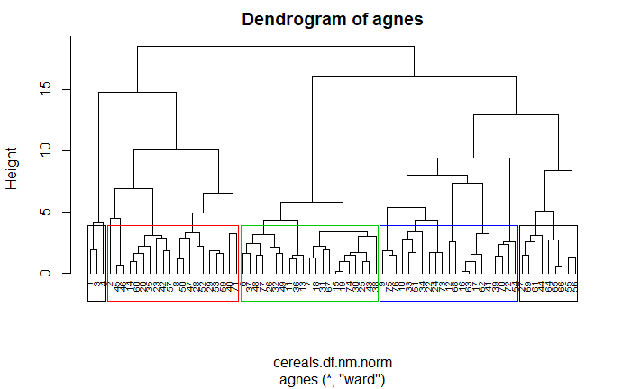

```r
pltree(hc_ward, cex = 0.6, hang = -1, main = "Dendrogram of agnes")
rect.hclust(hc_ward, k = 5, border = 1:4)
```

A distance of about 10 appears to give us 5 clusters.

```r
members <- cutree(hc_ward, k = 5) # cut 5 clusters
centers <- aggregate( . ~ members, data = cereals.df.nm[,-c(1:3)], FUN = mean)
centers
```

| members | calories | protein | fat | sodium | fiber | carbo | sugars | potass | vitamins | shelf | weight | cups | rating |
| --- | --- | --- | --- | --- | --- | --- | --- | --- | --- | --- | --- | --- | --- |
| 1 | 63.33333 | 4.000000 | 0.6666667 | 176.666667 | 11.0000000 | 6.666667 | 3.666667 | 310.00000 | 25.00000 | 3.000000 | 1.0000 | 0.3866667 | 73.84446 |
| 2 | 124.00000 | 3.150000 | 1.9500000 | 155.000000 | 3.1000000 | 13.950000 | 9.350000 | 151.50000 | 31.25000 | 2.900000 | 1.1725 | 0.6925000 | 38.26161 |
| 3 | 110.95238 | 1.523810 | 1.0000000 | 172.380952 | 0.5714286 | 12.619048 | 11.285714 | 45.95238 | 25.00000 | 1.666667 | 1.0000 | 0.8871429 | 28.84825 |
| 4 | 103.80952 | 2.714286 | 0.5238095 | 226.190476 | 1.6666667 | 18.476190 | 3.333333 | 73.80952 | 39.28571 | 2.095238 | 1.0000 | 0.9295238 | 46.46513 |
| 5 | 82.22222 | 2.444444 | 0.1111111 | 1.666667 | 2.1111111 | 15.333333 | 2.333333 | 90.55556 | 11.11111 | 2.000000 | 0.8700 | 0.8488889 | 63.01840 |

Cluster 5 is low in fat, sodium, and sugars, so probably represents the healthiest group of cereals.

#### Stability of Clusters

Let us now leave some observations off to determine cluster stability

[figure not shown]